# LeadsCaseStudy

## Importing the libraries for analysis.

```python
# Supress Warnings
import warnings
warnings.filterwarnings('ignore')

# Importing libraries
import numpy as np
import pandas as pd
import matplotlib.pyplot as plt
import seaborn as sns

# visulaisation
from matplotlib.pyplot import xticks
%matplotlib inline
```

## Reading the data from leads.csv source

```python
leads_df =pd.read_csv("Leads.csv")
leads_df.head()
```

|  | Prospect ID | Lead Number | Lead Origin | Lead Source | Do Not Email | Do Not Call | Converted | TotalVisits | Total Time Spent on Website | Page Views Per Visit | ... | Get updates on DM Content | Lead Profile | City | Asymmetrique Activity Index | Asymmetrique Profile Index | Asymmetrique Activity Score | Asymmetrique Profile Score | I agree to pay the amount through cheque | A free copy of Mastering The Interview | Last Notable Activity |
| --- | --- | --- | --- | --- | --- | --- | --- | --- | --- | --- | --- | --- | --- | --- | --- | --- | --- | --- | --- | --- | --- |
| 0 | 7927b2df-8bba-4d29-b9a2-b6e0beafe620 | 660737 | API | Olark Chat | No | No | 0 | 0.0 | 0 | 0.0 | ... | No | Select | Select | 02.Medium | 02.Medium | 15.0 | 15.0 | No | No | Modified |
| 1 | 2a272436-5132-4136-86fa-dcc88c88f482 | 660728 | API | Organic Search | No | No | 0 | 5.0 | 674 | 2.5 | ... | No | Select | Select | 02.Medium | 02.Medium | 15.0 | 15.0 | No | No | Email Opened |
| 2 | 8cc8c611-a219-4f35-ad23-fdfd2656bd8a | 660727 | Landing Page Submission | Direct Traffic | No | No | 1 | 2.0 | 1532 | 2.0 | ... | No | Potential Lead | Mumbai | 02.Medium | 01.High | 14.0 | 20.0 | No | Yes | Email Opened |
| 3 | 0cc2df48-7cf4-4e39-9de9-19797f9b38cc | 660719 | Landing Page Submission | Direct Traffic | No | No | 0 | 1.0 | 305 | 1.0 | ... | No | Select | Mumbai | 02.Medium | 01.High | 13.0 | 17.0 | No | No | Modified |
| 4 | 3256f628-e534-4826-9d63-4a8b88782852 | 660681 | Landing Page Submission | Google | No | No | 1 | 2.0 | 1428 | 1.0 | ... | No | Select | Mumbai | 02.Medium | 01.High | 15.0 | 18.0 | No | No | Modified |

5 rows × 37 columns

```python
# show all 37 columns
leads_df.columns
```

```
Index(['Prospect ID', 'Lead Number', 'Lead Origin', 'Lead Source',
       'Do Not Email', 'Do Not Call', 'Converted', 'TotalVisits',
       'Total Time Spent on Website', 'Page Views Per Visit', 'Last Activity',
       'Country', 'Specialization', 'How did you hear about X Education',
       'What is your current occupation',
       'What matters most to you in choosing a course', 'Search', 'Magazine',
       'Newspaper Article', 'X Education Forums', 'Newspaper',
       'Digital Advertisement', 'Through Recommendations',
       'Receive More Updates About Our Courses', 'Tags', 'Lead Quality',
       'Update me on Supply Chain Content', 'Get updates on DM Content',
       'Lead Profile', 'City', 'Asymmetrique Activity Index',
       'Asymmetrique Profile Index', 'Asymmetrique Activity Score',
       'Asymmetrique Profile Score',
       'I agree to pay the amount through cheque',
       'A free copy of Mastering The Interview', 'Last Notable Activity'],
      dtype='object')
```

General info() of the leads.csv

```python
#checking the info
leads_df.info()
```

```
<class 'pandas.core.frame.DataFrame'>
RangeIndex: 9240 entries, 0 to 9239
Data columns (total 37 columns):
Prospect ID                                      9240 non-null object
Lead Number                                      9240 non-null int64
Lead Origin                                      9240 non-null object
Lead Source                                      9204 non-null object
Do Not Email                                     9240 non-null object
Do Not Call                                      9240 non-null object
Converted                                        9240 non-null int64
TotalVisits                                      9103 non-null float64
Total Time Spent on Website                      9240 non-null int64
Page Views Per Visit                             9103 non-null float64
Last Activity                                    9137 non-null object
Country                                          6779 non-null object
Specialization                                   7802 non-null object
How did you hear about X Education               7033 non-null object
What is your current occupation                  6550 non-null object
What matters most to you in choosing a course    6531 non-null object
Search                                           9240 non-null object
Magazine                                         9240 non-null object
Newspaper Article                                9240 non-null object
X Education Forums                               9240 non-null object
Newspaper                                        9240 non-null object
Digital Advertisement                            9240 non-null object
Through Recommendations                          9240 non-null object
Receive More Updates About Our Courses           9240 non-null object
Tags                                             5887 non-null object
Lead Quality                                     4473 non-null object
Update me on Supply Chain Content                9240 non-null object
Get updates on DM Content                        9240 non-null object
Lead Profile                                     6531 non-null object
City                                             7820 non-null object
Asymmetrique Activity Index                      5022 non-null object
Asymmetrique Profile Index                       5022 non-null object
Asymmetrique Activity Score                      5022 non-null float64
Asymmetrique Profile Score                       5022 non-null float64
I agree to pay the amount through cheque         9240 non-null object
A free copy of Mastering The Interview           9240 non-null object
Last Notable Activity                            9240 non-null object
dtypes: float64(4), int64(3), object(30)
memory usage: 2.6+ MB
```

## Using the describe() on the Leads.csv to get a general sense of numerical columns

```python
leads_df.describe()
```

|  | Lead Number | Converted | TotalVisits | Total Time Spent on Website | Page Views Per Visit | Asymmetrique Activity Score | Asymmetrique Profile Score |
| --- | --- | --- | --- | --- | --- | --- | --- |
| count | 9240.000000 | 9240.000000 | 9103.000000 | 9240.000000 | 9103.000000 | 5022.000000 | 5022.000000 |
| mean | 617188.435606 | 0.385390 | 3.445238 | 487.698268 | 2.362820 | 14.306252 | 16.344883 |
| std | 23405.995698 | 0.486714 | 4.854853 | 548.021466 | 2.161418 | 1.386694 | 1.811395 |
| min | 579533.000000 | 0.000000 | 0.000000 | 0.000000 | 0.000000 | 7.000000 | 11.000000 |
| 25% | 596484.500000 | 0.000000 | 1.000000 | 12.000000 | 1.000000 | 14.000000 | 15.000000 |
| 50% | 615479.000000 | 0.000000 | 3.000000 | 248.000000 | 2.000000 | 14.000000 | 16.000000 |
| 75% | 637387.250000 | 1.000000 | 5.000000 | 936.000000 | 3.000000 | 15.000000 | 18.000000 |
| max | 660737.000000 | 1.000000 | 251.000000 | 2272.000000 | 55.000000 | 18.000000 | 20.000000 |

## The shape of leads.csv

```python
leads_df.shape
```

```
(9240, 37)
```

## The columns present in Leads.csv

```python
#checking duplicates
sum(leads_df.duplicated(subset = 'Prospect ID')) == 0
# No duplicate values
```

```
True
```

```python
# Converting 'Select' values to NaN.
leads_df = leads_df.replace('Select', np.nan)
```

## Data cleaning and manipulation

## Feature Distribution

```python
def type_features(data):
    categorical_features = data.select_dtypes(include = ["object"]).columns
    numerical_features = data.select_dtypes(exclude = ["object"]).columns
    print( "categorical_features :",categorical_features)
    print("numerical_features:",numerical_features)
    return categorical_features, numerical_features

leads_cat_features, leads_num_features =  type_features(leads_df)
```

```
categorical_features : Index(['Prospect ID', 'Lead Origin', 'Lead Source', 'Do Not Email',
       'Do Not Call', 'Last Activity', 'Country', 'Specialization',
       'How did you hear about X Education', 'What is your current occupation',
       'What matters most to you in choosing a course', 'Search', 'Magazine',
       'Newspaper Article', 'X Education Forums', 'Newspaper',
       'Digital Advertisement', 'Through Recommendations',
       'Receive More Updates About Our Courses', 'Tags', 'Lead Quality',
       'Update me on Supply Chain Content', 'Get updates on DM Content',
       'Lead Profile', 'City', 'Asymmetrique Activity Index',
       'Asymmetrique Profile Index',
       'I agree to pay the amount through cheque',
       'A free copy of Mastering The Interview', 'Last Notable Activity'],
      dtype='object')
numerical_features: Index(['Lead Number', 'Converted', 'TotalVisits',
       'Total Time Spent on Website', 'Page Views Per Visit',
       'Asymmetrique Activity Score', 'Asymmetrique Profile Score'],
      dtype='object')
```

```python
leads_df.isnull().sum().sort_values(ascending = False)
```

```
How did you hear about X Education               7250
Lead Profile                                     6855
Lead Quality                                     4767
Asymmetrique Profile Score                       4218
Asymmetrique Activity Score                      4218
Asymmetrique Profile Index                       4218
Asymmetrique Activity Index                      4218
City                                             3669
Specialization                                   3380
Tags                                             3353
What matters most to you in choosing a course    2709
What is your current occupation                  2690
Country                                          2461
TotalVisits                                       137
Page Views Per Visit                              137
Last Activity                                     103
Lead Source                                        36
Lead Origin                                         0
Lead Number                                         0
Do Not Email                                        0
Do Not Call                                         0
Converted                                           0
Total Time Spent on Website                         0
Last Notable Activity                               0
Newspaper Article                                   0
Search                                              0
Magazine                                            0
A free copy of Mastering The Interview              0
X Education Forums                                  0
Newspaper                                           0
Digital Advertisement                               0
Through Recommendations                             0
Receive More Updates About Our Courses              0
Update me on Supply Chain Content                   0
Get updates on DM Content                           0
I agree to pay the amount through cheque            0
Prospect ID                                         0
dtype: int64
```

```python
# function to analys missing values in a dataset

def missingdata(data):
    total = data.isnull().sum().sort_values(ascending = False)
    percent = (data.isnull().sum()/data.isnull().count()*100).sort_values(ascending = False)
    ms=pd.concat([total, percent], axis=1, keys=['Total', 'Percent'])
    ms= ms[ms["Percent"] > 40]
    f,ax =plt.subplots(figsize=(15,10))
    plt.xticks(rotation='90')
    fig=sns.barplot(ms.index, ms["Percent"])
    plt.xlabel('Features', fontsize=15)
    plt.ylabel('Percent of missing values', fontsize=15)
    plt.title('Percent missing data by Cloumns>40%', fontsize=15)
    return ms
```

|  | Total | Percent |
| --- | --- | --- |
| How did you hear about X Education | 7250 | 78.463203 |
| Lead Profile | 6855 | 74.188312 |
| Lead Quality | 4767 | 51.590909 |
| Asymmetrique Profile Score | 4218 | 45.649351 |
| Asymmetrique Activity Score | 4218 | 45.649351 |
| Asymmetrique Profile Index | 4218 | 45.649351 |
| Asymmetrique Activity Index | 4218 | 45.649351 |

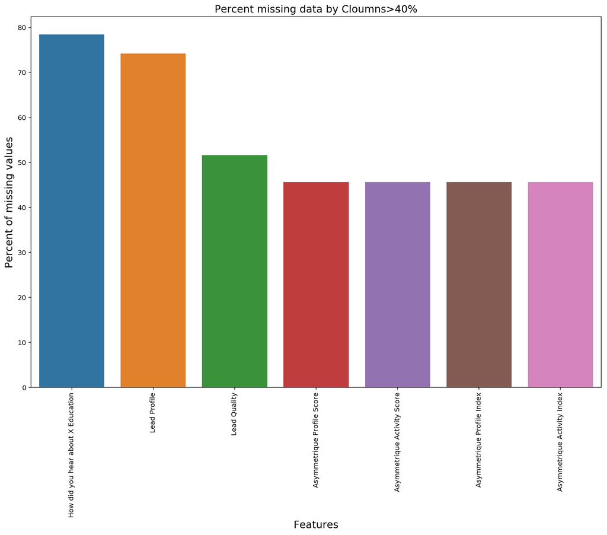

```python
missingdata(leads_df)
```

```python
round(100*(leads_df.isnull().sum()/len(leads_df.index)), 2)
```

```
Prospect ID                                       0.00
Lead Number                                       0.00
Lead Origin                                       0.00
Lead Source                                       0.39
Do Not Email                                      0.00
Do Not Call                                       0.00
Converted                                         0.00
TotalVisits                                       1.48
Total Time Spent on Website                       0.00
Page Views Per Visit                              1.48
Last Activity                                     1.11
Country                                          26.63
Specialization                                   36.58
How did you hear about X Education               78.46
What is your current occupation                  29.11
What matters most to you in choosing a course    29.32
Search                                            0.00
Magazine                                          0.00
Newspaper Article                                 0.00
X Education Forums                                0.00
Newspaper                                         0.00
Digital Advertisement                             0.00
Through Recommendations                           0.00
Receive More Updates About Our Courses            0.00
Tags                                             36.29
Lead Quality                                     51.59
Update me on Supply Chain Content                 0.00
Get updates on DM Content                         0.00
Lead Profile                                     74.19
City                                             39.71
Asymmetrique Activity Index                      45.65
Asymmetrique Profile Index                       45.65
Asymmetrique Activity Score                      45.65
Asymmetrique Profile Score                       45.65
I agree to pay the amount through cheque          0.00
A free copy of Mastering The Interview            0.00
Last Notable Activity                             0.00
dtype: float64
```

## Dropping the column having more than 70% of null values

```python
leads_df=leads_df.drop(['Lead Profile', 'How did you hear about X Education'],axis=1)
```

## Now checking the null values one by one

## Lead Quality Indicates the quality of lead based on the data and intuition the the employee who has been assigned to the lead.

```python
leads_df['Lead Quality'].describe()
```

```
count         4473
unique           5
top       Might be
freq          1560
Name: Lead Quality, dtype: object
```

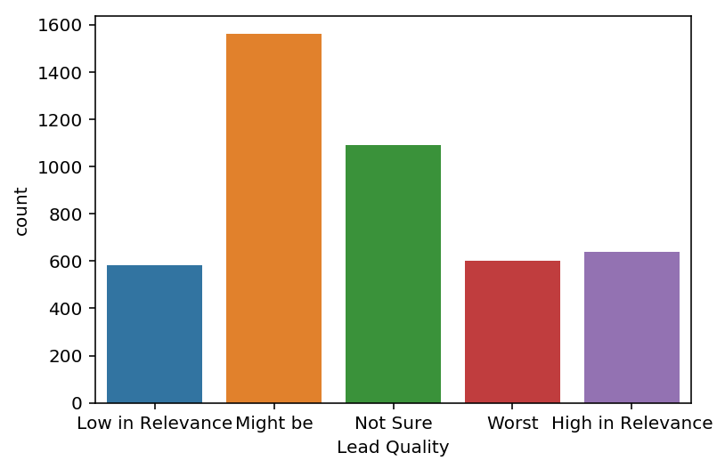

```python
sns.countplot(leads_df['Lead Quality'])
```

## It has around 51% of the null values, so we can impute the null values as Not sure as it is totally based on intution of the employee therefor filling Nan as Not sure will not has any diverse effect on thed dataset.

```python
leads_df['Lead Quality'] = leads_df['Lead Quality'].replace(np.nan, 'Not Sure')
```

## City The city of the customer.

```python
leads_df['City'].describe()
```

```
count       5571
unique         6
top       Mumbai
freq        3222
Name: City, dtype: object
```

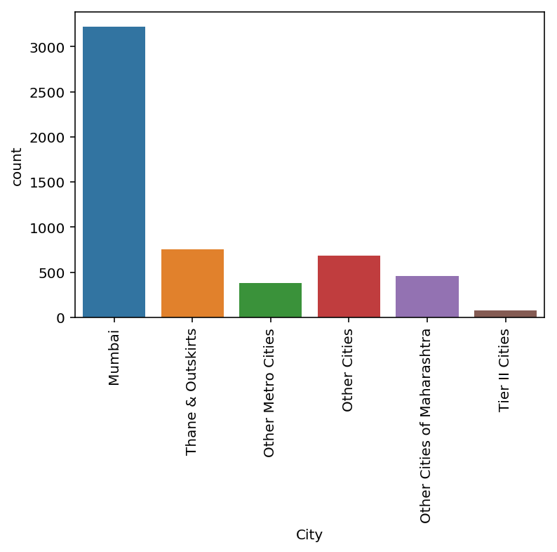

```python
sns.countplot(leads_df['City'])
xticks(rotation = 90)
```

## Here we can't impute the Rest of India as a categories because it has Other cities teling us the same thing.o what we can do is impute Mumbai in place of Nan as it has max count.

```python
leads_df['City']=leads_df['City'].replace(np.nan,'Mumbai')
```

# Tags Tags assigned to customers indicating the current status of the lead.

```python
leads_df['Tags'].describe()
```

```
count                                    5887
unique                                     26
top       Will revert after reading the email
freq                                     2072
Name: Tags, dtype: object
```

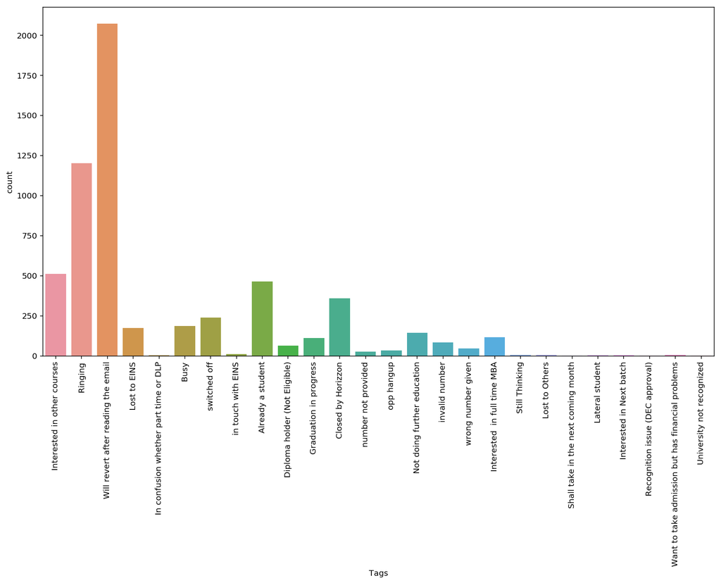

```python
fig, axs = plt.subplots(figsize = (15,8))
sns.countplot(leads_df['Tags'])
xticks(rotation = 90)
```

## Here basically null values indicate that sales person are waiting for the customer to respond means they have not revert back. So sales team have either contacted them. So We can replace Nan values to Will revert after reading the email.

```python
leads_df['Tags']=leads_df['Tags'].replace(np.nan, 'Will revert after reading the email')
```

## An index and score assigned to each customer based on their activity and their profile

- Asymmetrique Activity Index
- Asymmetrique Profile Index
- Asymmetrique Activity Score
- Asymmetrique Profile Score

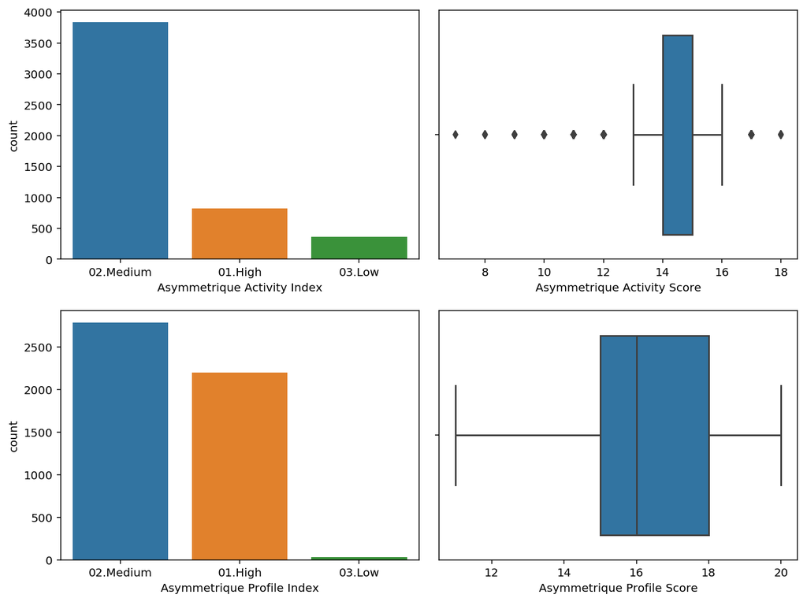

```python
fig, axs = plt.subplots(2,2, figsize = (10,7.5))
plt1 = sns.countplot(leads_df['Asymmetrique Activity Index'], ax = axs[0,0])
plt2 = sns.boxplot(leads_df['Asymmetrique Activity Score'], ax = axs[0,1])
plt3 = sns.countplot(leads_df['Asymmetrique Profile Index'], ax = axs[1,0])
plt4 = sns.boxplot(leads_df['Asymmetrique Profile Score'], ax = axs[1,1])
plt.tight_layout()
```

## There is around 45% of the null values and too much variation. So nothing can be impute as such. So it's better to drop these columns directlty

```python
leads_df=leads_df.drop(['Asymmetrique Activity Index', 'Asymmetrique Activity Score','Asymmetrique Profile Index','Asymmetrique Profile Score'],axis=1)
```

Country The country of the customer.

```python
leads_df['Country'].describe()
```

```
count      6779
unique       38
top       India
freq       6492
Name: Country, dtype: object
```

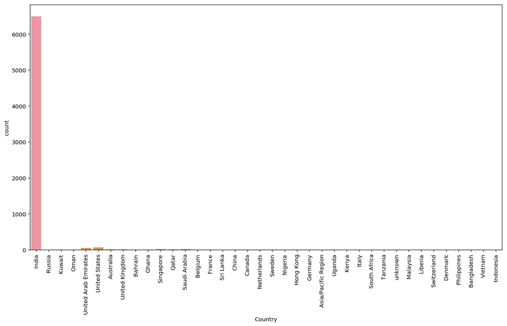

```python
fig, axs = plt.subplots(figsize = (15,8))
sns.countplot(leads_df['Country'])
xticks(rotation = 90)
```

In this India has most of the values so we can import India in place of Nan.

```python
leads_df['Country']=leads_df['Country'].replace(np.nan,'India')
```

Specialization The industry domain in which the customer worked before. Includes the level 'Select Specialization' which means the customer had not selected this option while filling the form.

```python
leads_df['Specialization'].describe()
```

```
count                   5860
unique                    18
top       Finance Management
freq                     976
Name: Specialization, dtype: object
```

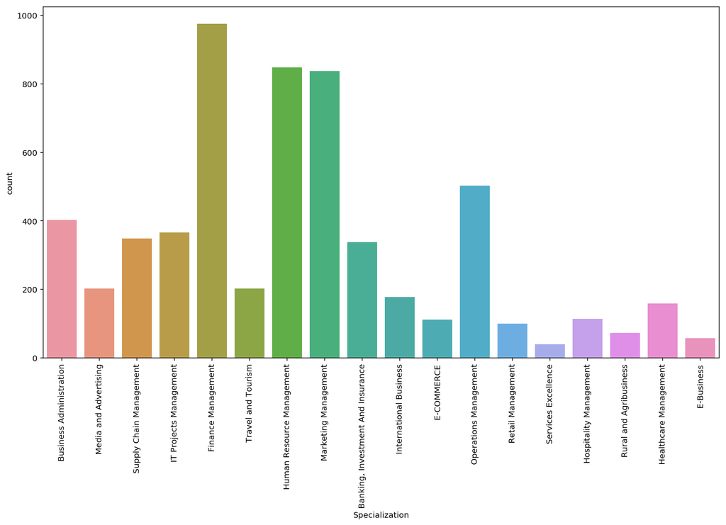

```python
fig, axs = plt.subplots(figsize = (15,8))
sns.countplot(leads_df['Specialization'])
xticks(rotation = 90)
```

Here we can replace the null values by creating a new catergory called Others which will indicate the specialization other than the mentioned in the dataset.

```python
leads_df['Specialization']=leads_df['Specialization'].replace(np.nan,'Others')
```

What is your current occupation Indicates whether the customer is a student, umemployed or employed.

```python
leads_df['What is your current occupation'].describe()
```

```
count           6550
unique             6
top       Unemployed
freq            5600
Name: What is your current occupation, dtype: object
```

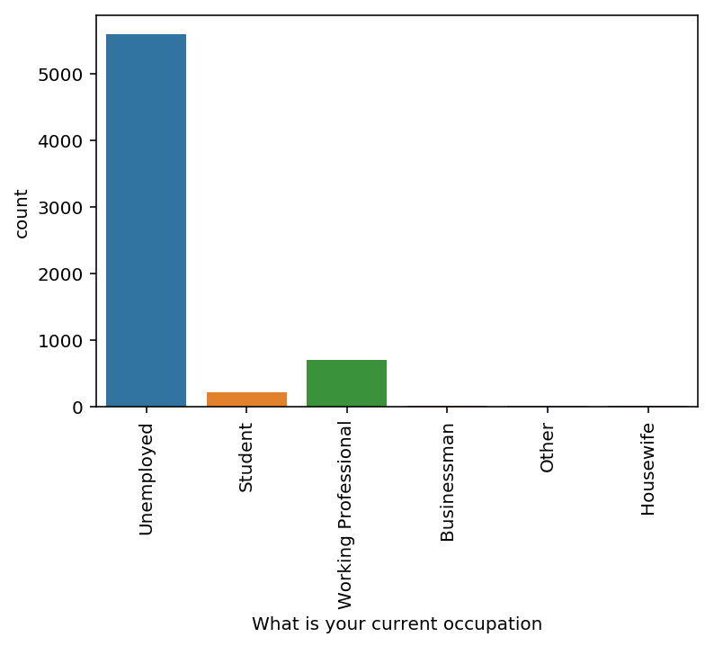

```python
sns.countplot(leads_df['What is your current occupation'])
xticks(rotation = 90)
```

Max values is unemployed so we can impute Unemployed in place of Nan

```python
leads_df['What is your current occupation']=leads_df['What is your current occupation'].replace(np.nan,'Unemployed')
```

What matters most to you in choosing this course An option selected by the customer indicating what is their main motto behind doing this course.

```python
leads_df['What matters most to you in choosing a course'].describe()
```

```
count                        6531
unique                          3
top       Better Career Prospects
freq                         6528
Name: What matters most to you in choosing a course, dtype: object
```

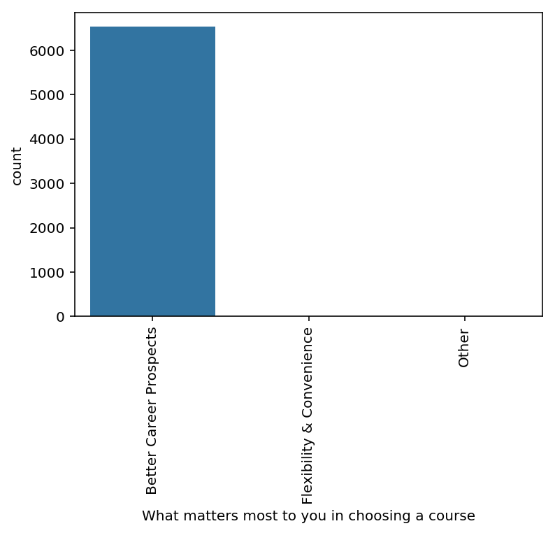

```python
sns.countplot(leads_df['What matters most to you in choosing a course'])
xticks(rotation=90)
```

Here we already have others as acategory and majority goes with Better carrer Prospect.So we can easily impute better carrer prospect in place of NaN

```python
leads_df['What matters most to you in choosing a course']=leads_df['What matters most to you in choosing a course'].replace(np.nan,'Better Career Prospects')
```

Checking the null values again

```python
round(100*(leads_df.isnull().sum()/len(leads_df.index)), 2)
```

```
Prospect ID                                      0.00
Lead Number                                      0.00
Lead Origin                                      0.00
Lead Source                                      0.39
Do Not Email                                     0.00
Do Not Call                                      0.00
Converted                                        0.00
TotalVisits                                      1.48
Total Time Spent on Website                      0.00
Page Views Per Visit                             1.48
Last Activity                                    1.11
Country                                          0.00
Specialization                                   0.00
What is your current occupation                  0.00
What matters most to you in choosing a course    0.00
Search                                           0.00
Magazine                                         0.00
Newspaper Article                                0.00
X Education Forums                               0.00
Newspaper                                        0.00
Digital Advertisement                            0.00
Through Recommendations                          0.00
Receive More Updates About Our Courses           0.00
Tags                                             0.00
Lead Quality                                     0.00
Update me on Supply Chain Content                0.00
Get updates on DM Content                        0.00
City                                             0.00
I agree to pay the amount through cheque         0.00
A free copy of Mastering The Interview           0.00
Last Notable Activity                            0.00
dtype: float64
```

Now we have remaining less than 2% of the null values.So we can esily drop them as it will not affect the data.

```python
leads_df.dropna(inplace = True)
```

Checking the null values for the final time

```python
round(100*(leads_df.isnull().sum()/len(leads_df.index)), 2)
```

```
Prospect ID                                      0.0
Lead Number                                      0.0
Lead Origin                                      0.0
Lead Source                                      0.0
Do Not Email                                     0.0
Do Not Call                                      0.0
Converted                                        0.0
TotalVisits                                      0.0
Total Time Spent on Website                      0.0
Page Views Per Visit                             0.0
Last Activity                                    0.0
Country                                          0.0
Specialization                                   0.0
What is your current occupation                  0.0
What matters most to you in choosing a course    0.0
Search                                           0.0
Magazine                                         0.0
Newspaper Article                                0.0
X Education Forums                               0.0
Newspaper                                        0.0
Digital Advertisement                            0.0
Through Recommendations                          0.0
Receive More Updates About Our Courses           0.0
Tags                                             0.0
Lead Quality                                     0.0
Update me on Supply Chain Content                0.0
Get updates on DM Content                        0.0
City                                             0.0
I agree to pay the amount through cheque         0.0
A free copy of Mastering The Interview           0.0
Last Notable Activity                            0.0
dtype: float64
```

Now we have impute the data now we can move to Univariate and bivariate analysis

# Data Imbalace wrt to Target Varibale

Here the Target Variable is Converted

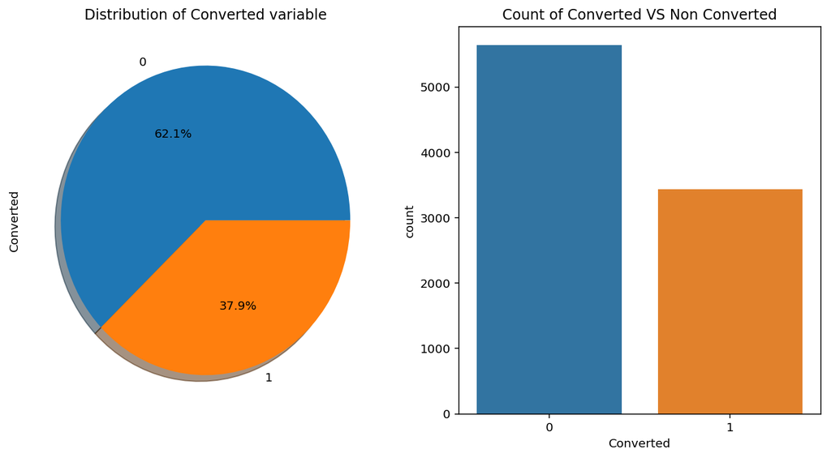

```python
f,ax=plt.subplots(1,2,figsize=(12,6))
leads_df.Converted.value_counts().plot.pie(autopct='%1.1f%%',ax=ax[0],shadow=True)
ax[0].set_title('Distribution of Converted variable')
sns.countplot('Converted',data=leads_df,ax=ax[1])
ax[1].set_title('Count of Converted VS Non Converted')
plt.show()
```

Here around 38% are converted.

# Now Univariate and bivariate Analysis

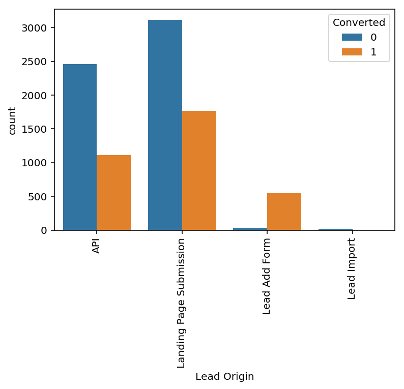

```python
sns.countplot(x = "Lead Origin", hue = "Converted", data = leads_df)
xticks(rotation = 90)
```

Checking 'Leads Origin' Here the converison rate of API and Leads Add Forum and Landing Page submission are considerable.So we need to focus on these if we want to improve the conversion rate

Lead Source

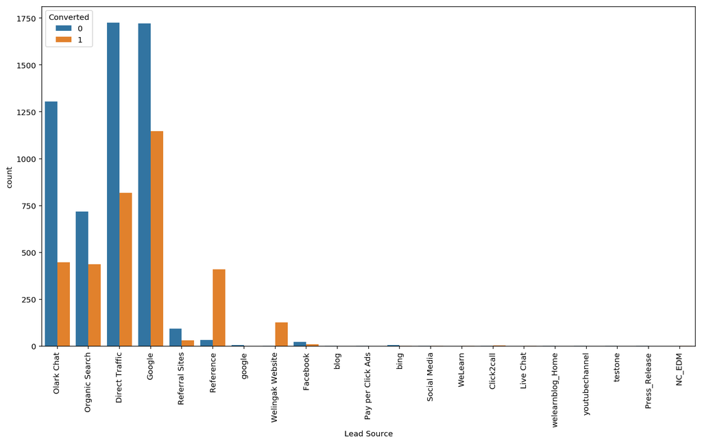

```python
fig, axs = plt.subplots(figsize = (15,8))
sns.countplot(x = "Lead Source", hue = "Converted", data = leads_df)
xticks(rotation = 90)
```

Here we have to do two things.First of all there are 2 categories which are same ie Google and google.So we need to replace google with Google and after that categories like 'Click2call', 'Live Chat', 'NC_EDM', 'Pay per Click Ads', 'Press_Release','Social Media', 'WeLearn', 'bing', 'blog', 'testone', 'welearnblog_Home', 'youtubechannel' we can convert them to others . as they don't have much values present in them.

```python
leads_df['Lead Source'] = leads_df['Lead Source'].replace(['google'], 'Google')
leads_df['Lead Source'] = leads_df['Lead Source'].replace(['Click2call', 'Live Chat', 'NC_EDM', 'Pay per Click Ads', 'Press_Release',
  'Social Media', 'WeLearn', 'bing', 'blog', 'testone', 'welearnblog_Home', 'youtubechannel'], 'Others')
```

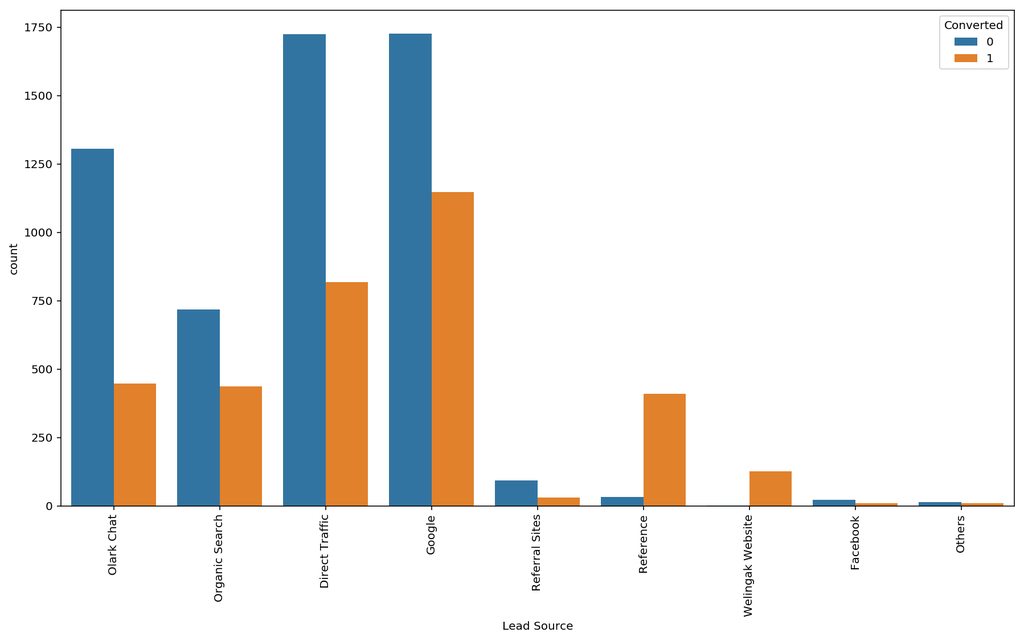

```python
fig, axs = plt.subplots(figsize = (15,8))
sns.countplot(x = "Lead Source", hue = "Converted", data = leads_df)
xticks(rotation = 90)
```

To improve conversion rate, our focus should be on improving lead converion of olark chat, organic search, direct traffic, and google leads and generate more leads from reference and welingak website.

Do Not Email An indicator variable selected by the customer wherein they select whether of not they want to be emailed about the course or not. Do Not Call An indicator variable selected by the customer wherein they select whether of not they want to be called about the course or not.

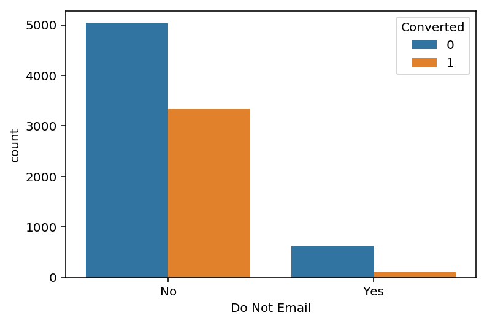

```python
sns.countplot(x = "Do Not Email", hue = "Converted", data = leads_df)
```

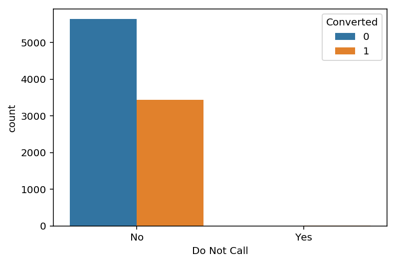

```python
sns.countplot(x = "Do Not Call", hue = "Converted", data = leads_df)
```

TotalVisits The total number of visits made by the customer on the website.

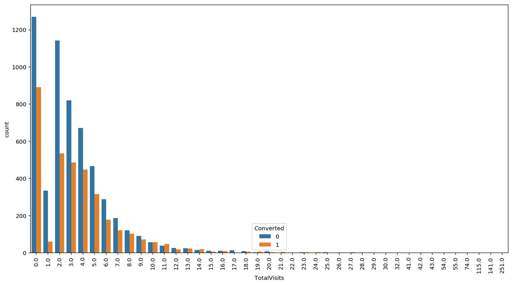

```python
fig, axs = plt.subplots(figsize = (15,8))
sns.countplot(x = "TotalVisits", hue = "Converted", data = leads_df)
xticks(rotation=90)
```

Seems like data is varying.Now let us check the describe of Total Visits

```python
leads_df['TotalVisits'].describe()
```

```
count    9074.000000
mean        3.456028
std         4.858802
min         0.000000
25%         1.000000
50%         3.000000
75%         5.000000
max       251.000000
Name: TotalVisits, dtype: float64
```

As the min value is 0 and max value is 251 it seems like outlier.Let's plot the box plot now.

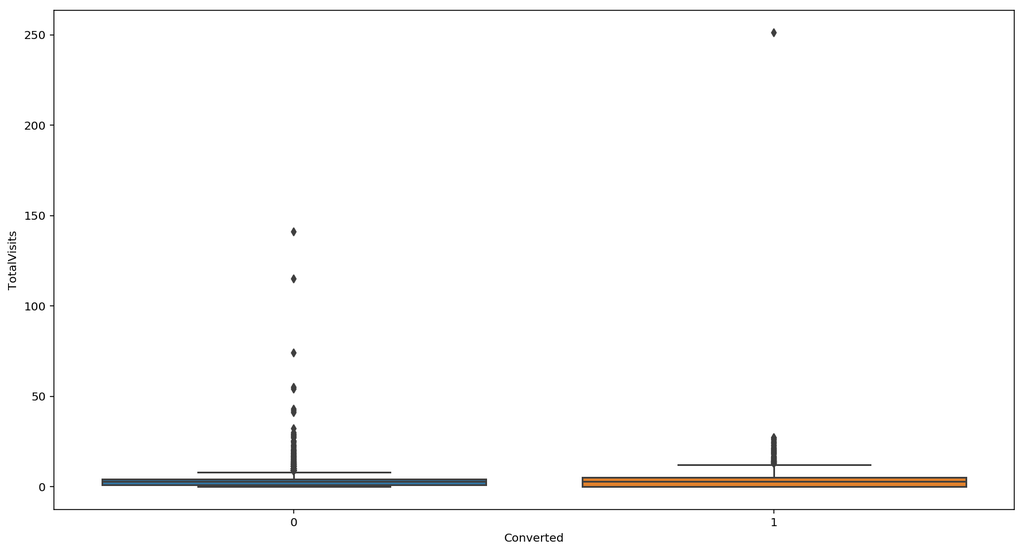

```python
fig, axs = plt.subplots(figsize = (15,8))
sns.boxplot(y = 'TotalVisits', x = 'Converted', data = leads_df)
```

Clearly we can see outlier here.So now doing outlier treatment.

```python
percentiles = leads_df['TotalVisits'].quantile([0.05,0.95]).values
leads_df['TotalVisits'][leads_df['TotalVisits'] <= percentiles[0]] = percentiles[0]
leads_df['TotalVisits'][leads_df['TotalVisits'] >= percentiles[1]] = percentiles[1]
```

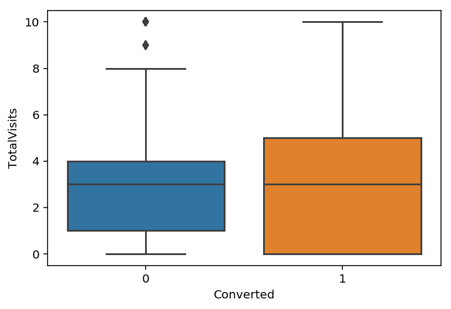

```python
sns.boxplot(y = 'TotalVisits', x = 'Converted', data = leads_df)
```

Median is same but nothing important regarding conversion rate can be study here.

Total Time Spent on Website The total time spent by the customer on the website.Here the value of this column ranges from 0-2272 So we can't plot countplot here.We need to go with describe and check for outliers.

```python
leads_df['Total Time Spent on Website'].describe()
```

```
count    9074.000000
mean      482.887481
std       545.256560
min         0.000000
25%        11.000000
50%       246.000000
75%       922.750000
max      2272.000000
Name: Total Time Spent on Website, dtype: float64
```

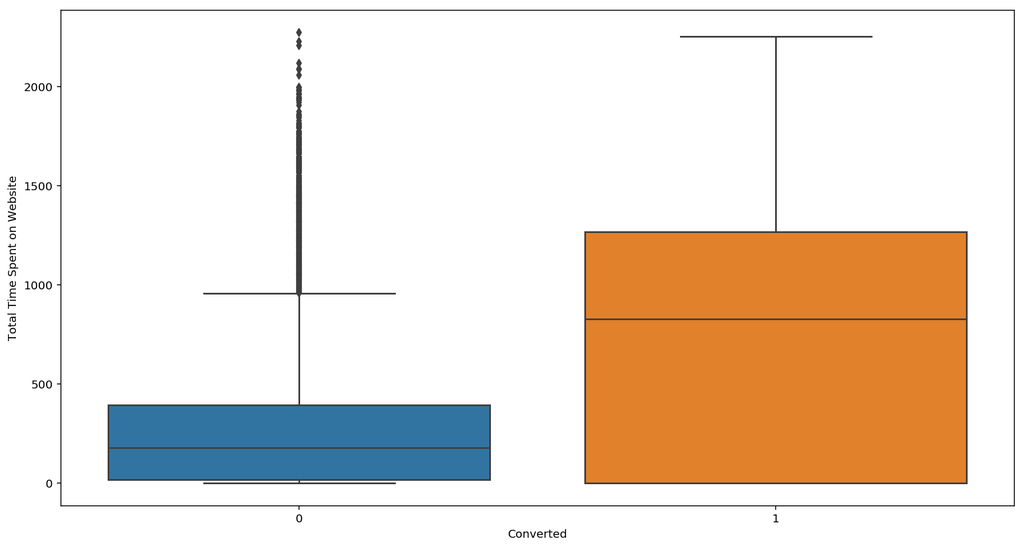

```python
fig, axs = plt.subplots(figsize = (15,8))
sns.boxplot(y = 'Total Time Spent on Website', x = 'Converted', data = leads_df)
```

Clearly we can see that leads who spend most of the time on website are most likely to be converted.

Page Views Per Visit Average number of pages on the website viewed during the visits.

```python
leads_df['Page Views Per Visit'].describe()
```

```
count    9074.000000
mean        2.370151
std         2.160871
min         0.000000
25%         1.000000
50%         2.000000
75%         3.200000
max        55.000000
Name: Page Views Per Visit, dtype: float64
```

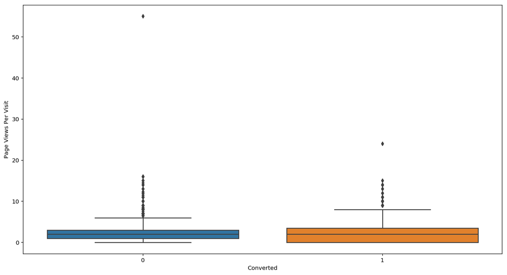

```python
fig, axs = plt.subplots(figsize = (15,8))
sns.boxplot(y = 'Page Views Per Visit', x = 'Converted', data = leads_df)
```

Clearly we can see outliers.So we are doing the outlier treatment the same way we have done above.

```python
percentiles = leads_df['Page Views Per Visit'].quantile([0.05,0.95]).values
leads_df['Page Views Per Visit'][leads_df['Page Views Per Visit'] <= percentiles[0]] = percentiles[0]
leads_df['Page Views Per Visit'][leads_df['Page Views Per Visit'] >= percentiles[1]] = percentiles[1]
```

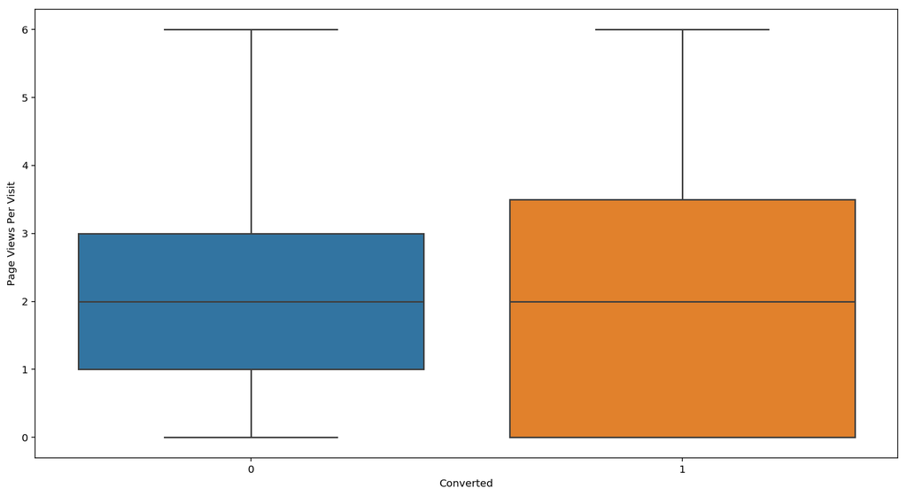

```python
fig, axs = plt.subplots(figsize = (15,8))
sns.boxplot(y = 'Page Views Per Visit', x = 'Converted', data = leads_df)
```

Median are same but nothing conclusive can be drawn from here.

Last Activity Last activity performed by the customer. Includes Email Opened, Olark Chat Conversation, etc.

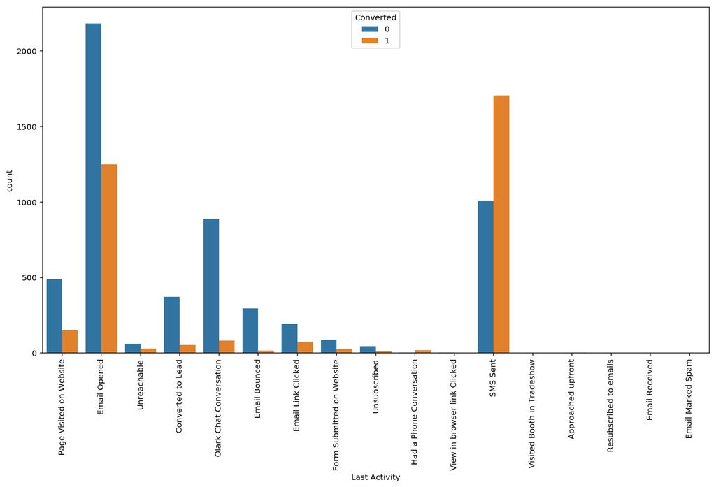

```python
fig, axs = plt.subplots(figsize = (15,8))
sns.countplot(x = "Last Activity", hue = "Converted", data = leads_df)
xticks(rotation = 90)
```

We can convert 'Had a Phone Conversation', 'View in browser link Clicked', 'Visited Booth in Tradeshow', 'Approached upfront','Resubscribed to emails','Email Received', 'Email Marked Spam' into others as their count are very less.

```python
leads_df['Last Activity'] = leads_df['Last Activity'].replace(['Had a Phone Conversation', 'View in browser link Clicked',
                                                       'Visited Booth in Tradeshow', 'Approached upfront',
                                                       'Resubscribed to emails','Email Received', 'Email Marked Spam'], 'Others')
```

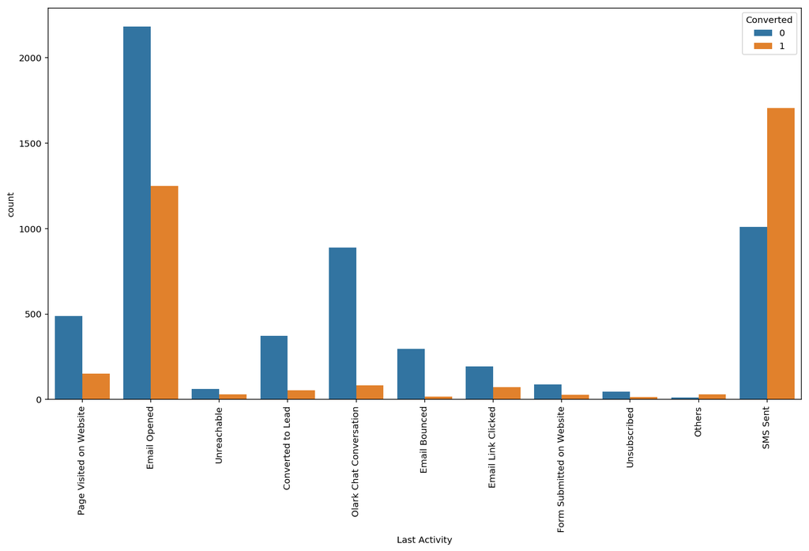

```python
fig, axs = plt.subplots(figsize = (15,8))
sns.countplot(x = "Last Activity", hue = "Converted", data = leads_df)
xticks(rotation = 90)
```

Country The country of the customer.

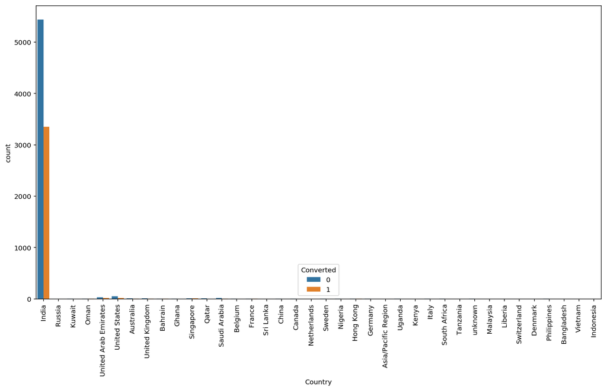

```python
fig, axs = plt.subplots(figsize = (15,8))
sns.countplot(x = "Country", hue = "Converted", data = leads_df)
xticks(rotation = 90)
```

Mostly leads is of India.So nothing we can catch from here.

Specialization The industry domain in which the customer worked before. Includes the level 'Select Specialization' which means the customer had not selected this option while filling the form.

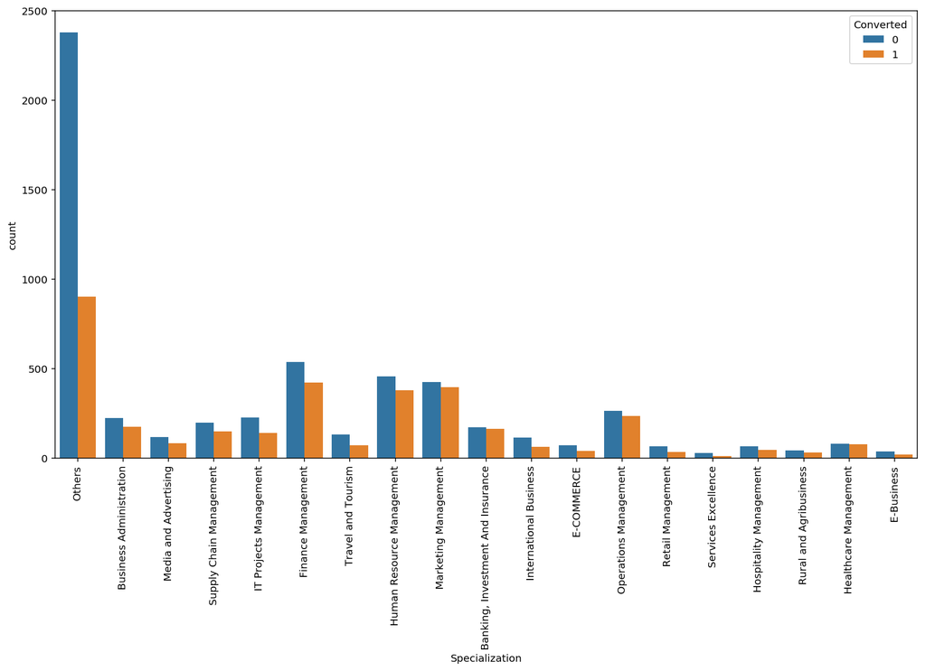

```python
fig, axs = plt.subplots(figsize = (15,8))
sns.countplot(x = "Specialization", hue = "Converted", data = leads_df)
xticks(rotation = 90)
```

It can be an important feature as the data is showig lead conversion of many specialization.

What is your current occupation Indicates whether the customer is a student, umemployed or employed.

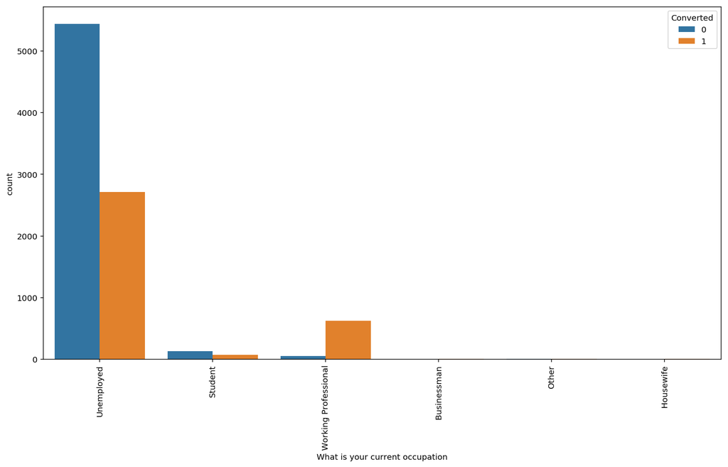

```python
fig, axs = plt.subplots(figsize = (15,8))
sns.countplot(x = "What is your current occupation", hue = "Converted", data = leads_df)
xticks(rotation = 90)
```

Working professionals have higher conversion rate

What matters most to you in choosing this course An option selected by the customer indicating what is their main motto behind doing this course. Nothing can be drawn from it which could help in conversion rate.

```python
leads_df['What matters most to you in choosing a course'].describe()
```

```
count                        9074
unique                          3
top       Better Career Prospects
freq                         9072
Name: What matters most to you in choosing a course, dtype: object
```

Search Indicating whether the customer had seen the ad in any of the listed items. Magazine  
Newspaper Article  
X Education Forums  
Newspaper  
Digital Advertisement  
Nothing can be drawn from it which could help in conversion rate.

```python
leads_df['Search'].describe()
```

```
count     9074
unique       2
top         No
freq      9060
Name: Search, dtype: object
```

```python
leads_df['Magazine'].describe()
```

```
count     9074
unique       1
top         No
freq      9074
Name: Magazine, dtype: object
```

```python
leads_df['Newspaper Article'].describe()
```

```
count     9074
unique       2
top         No
freq      9072
Name: Newspaper Article, dtype: object
```

```python
leads_df['X Education Forums'].describe()
```

```
count     9074
unique       2
top         No
freq      9073
Name: X Education Forums, dtype: object
```

```python
leads_df['Newspaper'].describe()
```

```
count     9074
unique       2
top         No
freq      9073
Name: Newspaper, dtype: object
```

```python
leads_df['Digital Advertisement'].describe()
```

```
count     9074
unique       2
top         No
freq      9070
Name: Digital Advertisement, dtype: object
```

Through Recommendations Indicates whether the customer came in through recommendations. Receive More Updates About Our Courses Indicates whether the customer chose to receive more updates about the courses. Nothing can be drwan from it.

```python
leads_df['Through Recommendations'].describe()
```

```
count     9074
unique       2
top         No
freq      9067
Name: Through Recommendations, dtype: object
```

```python
leads_df['Receive More Updates About Our Courses'].describe()
```

```
count     9074
unique       1
top         No
freq      9074
Name: Receive More Updates About Our Courses, dtype: object
```

Tags Tags assigned to customers indicating the current status of the lead.

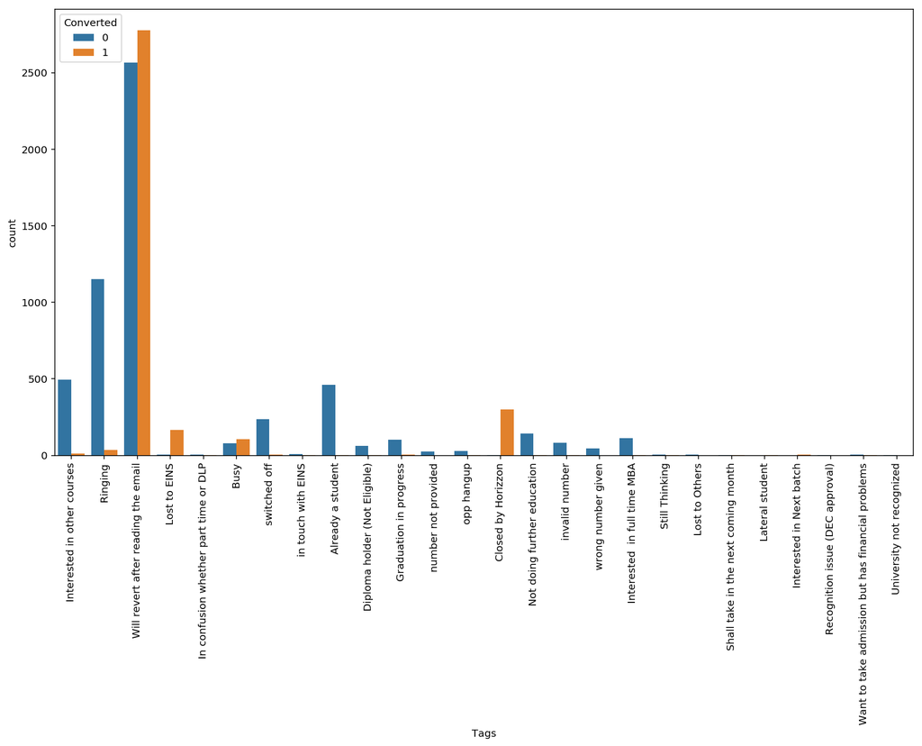

```python
fig, axs = plt.subplots(figsize = (15,8))
sns.countplot(x = "Tags", hue = "Converted", data = leads_df)
xticks(rotation = 90)
```

Let's keep the Tags which are of more use and help us and replace 'In confusion whether part time or DLP', 'in touch with EINS','Diploma holder (Not Eligible)', 'Approached upfront','Graduation in progress','number not provided', 'opp hangup','Still Thinking','Lost to Others','Shall take in the next coming month','Lateral student','Interested in Next batch','Recognition issue (DEC approval)','Want to take admission but has financial problems','University not recognized' with others

```python
leads_df['Tags'] = leads_df['Tags'].replace(['In confusion whether part time or DLP', 'in touch with EINS','Diploma holder (Not Eligible)',
                                     'Approached upfront','Graduation in progress','number not provided', 'opp hangup','Still Thinking',
                                    'Lost to Others','Shall take in the next coming month','Lateral student','Interested in Next batch',
                                    'Recognition issue (DEC approval)','Want to take admission but has financial problems',
                                    'University not recognized'], 'Others')
```

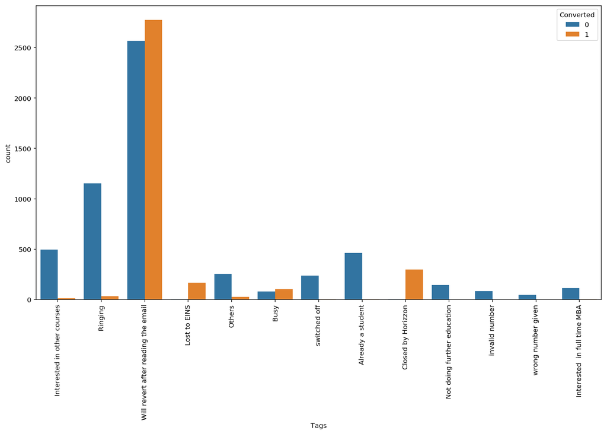

```python
fig, axs = plt.subplots(figsize = (15,8))
sns.countplot(x = "Tags", hue = "Converted", data = leads_df)
xticks(rotation = 90)
```

Will revert after the email seems to be high in coversion rate.

Lead Quality Indicates the quality of lead based on the data and intuition the the employee who has been assigned to the lead.

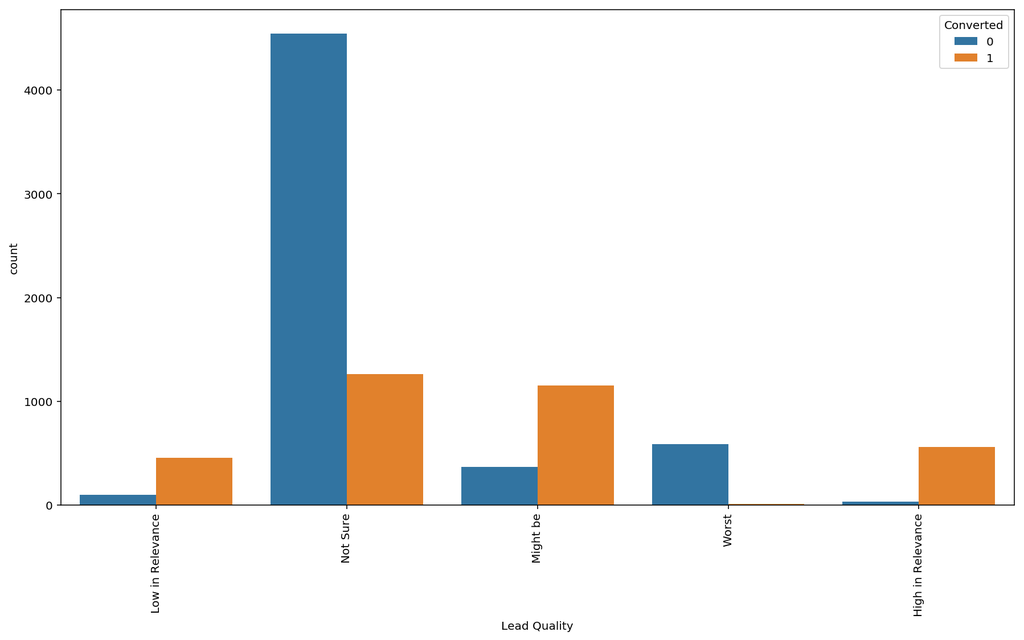

```python
fig, axs = plt.subplots(figsize = (15,8))
sns.countplot(x = "Lead Quality", hue = "Converted", data = leads_df)
xticks(rotation = 90)
```

Update me on Supply Chain Content Indicates whether the customer wants updates on the Supply Chain Content. Nothing useful can be drwan.

```python
leads_df['Update me on Supply Chain Content'].describe()
```

```
count     9074
unique       1
top         No
freq      9074
Name: Update me on Supply Chain Content, dtype: object
```

Get updates on DM Content Indicates whether the customer wants updates on the DM Content. I agree to pay the amount through cheque Indicates whether the customer has agreed to pay the amount through cheque or not. a free copy of Mastering The Interview Indicates whether the customer wants a free copy of 'Mastering the Interview' or not. Nothing can drwan which could help us in the conversion rate.

```python
leads_df['Get updates on DM Content'].describe()
```

```
count     9074
unique       1
top         No
freq      9074
Name: Get updates on DM Content, dtype: object
```

```python
leads_df['I agree to pay the amount through cheque'].describe()
```

```
count     9074
unique       1
top         No
freq      9074
Name: I agree to pay the amount through cheque, dtype: object
```

```python
leads_df['A free copy of Mastering The Interview'].describe()
```

```
count     9074
unique       2
top         No
freq      6186
Name: A free copy of Mastering The Interview, dtype: object
```

City The city of the customer.

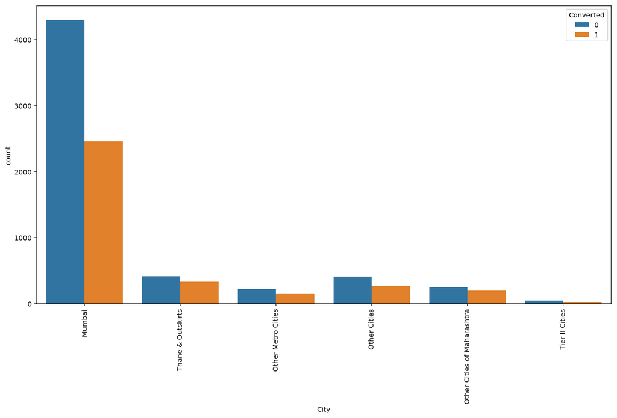

```python
fig, axs = plt.subplots(figsize = (15,8))
sns.countplot(x = "City", hue = "Converted", data = leads_df)
xticks(rotation = 90)
```

Last Notable Activity The last notable acitivity performed by the student.

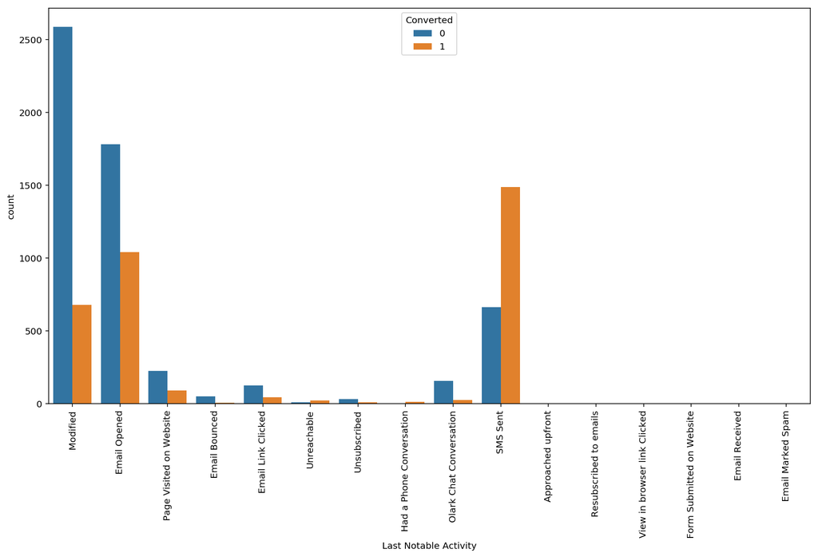

```python
fig, axs = plt.subplots(figsize = (15,8))
sns.countplot(x = "Last Notable Activity", hue = "Converted", data = leads_df)
xticks(rotation = 90)
```

Conclusion of Analysis So far There are many columns like: 1)Lead Number 2)What matters most to you in choosing a course 3)Search 4)Magazine 5)Newspaper Article 6)X Education Forums 7)Newspaper 8)Digital Advertisement 9)Through Recommendations 10)Receive More Updates About Our Courses 11)Update me on Supply Chain Content 12)Get updates on DM Content 13)I agree to pay the amount through cheque 14)A free copy of Mastering The Interview 15)Country So we can drop these columns:

```python
leads_df = leads_df.drop(['Lead Number','What matters most to you in choosing a course','Search','Magazine','Newspaper Article','X Education Forums','Newspaper','Digital Advertisement','Through Recommendations','Receive More Updates About Our Courses','Update me on Supply Chain Content',
'Get updates on DM Content','I agree to pay the amount through cheque','A free copy of Mastering The Interview','Country'],1)
```

```python
leads_df.shape
```

```
(9074, 16)
```

# Data Prepration

Converting Yes/No to 0/1

```python
#now only two columns are left with Yes/No ie 'Do Not Email', 'Do Not Call'
list =  ['Do Not Email', 'Do Not Call']
def binary(x):
    return x.map({'Yes': 1, "No": 0})


leads_df[list] = leads_df[list].apply(binary)
```

Now we have to do one hot encoding for below columns: 1)Lead Origin 2)Last Activity 3)Specialization 4)What is your current occupation 5)Tags 6)Lead Quality 7)City 8)Last Notable Activity 9)Lead Source

```python
onehot_df = pd.get_dummies(leads_df[['Lead Origin', 'Lead Source', 'Last Activity', 'Specialization','What is your current occupation',
                              'Tags','Lead Quality','City','Last Notable Activity']], drop_first=True)
onehot_df.head()
```

|  | Lead Origin_Landing Page Submission | Lead Origin_Lead Add Form | Lead Origin_Lead Import | Lead Source_Facebook | Lead Source_Google | Lead Source_Olark Chat | Lead Source_Organic Search | Lead Source_Others | Lead Source_Reference | Lead Source_Referral Sites | ... | Last Notable Activity_Form Submitted on Website | Last Notable Activity_Had a Phone Conversation | Last Notable Activity_Modified | Last Notable Activity_Olark Chat Conversation | Last Notable Activity_Page Visited on Website | Last Notable Activity_Resubscribed to emails | Last Notable Activity_SMS Sent | Last Notable Activity_Unreachable | Last Notable Activity_Unsubscribed | Last Notable Activity_View in browser link Clicked |
| --- | --- | --- | --- | --- | --- | --- | --- | --- | --- | --- | --- | --- | --- | --- | --- | --- | --- | --- | --- | --- | --- |
| 0 | 0 | 0 | 0 | 0 | 0 | 1 | 0 | 0 | 0 | 0 | ... | 0 | 0 | 1 | 0 | 0 | 0 | 0 | 0 | 0 | 0 |
| 1 | 0 | 0 | 0 | 0 | 0 | 0 | 1 | 0 | 0 | 0 | ... | 0 | 0 | 0 | 0 | 0 | 0 | 0 | 0 | 0 | 0 |
| 2 | 1 | 0 | 0 | 0 | 0 | 0 | 0 | 0 | 0 | 0 | ... | 0 | 0 | 0 | 0 | 0 | 0 | 0 | 0 | 0 | 0 |
| 3 | 1 | 0 | 0 | 0 | 0 | 0 | 0 | 0 | 0 | 0 | ... | 0 | 0 | 1 | 0 | 0 | 0 | 0 | 0 | 0 | 0 |
| 4 | 1 | 0 | 0 | 0 | 1 | 0 | 0 | 0 | 0 | 0 | ... | 0 | 0 | 1 | 0 | 0 | 0 | 0 | 0 | 0 | 0 |

5 rows × 80 columns

```python
#Now we have to merge the onehot data frame with the original one:
leads_df = pd.concat([leads_df, onehot_df], axis=1)
leads_df.head()
```

|  | Prospect ID | Lead Origin | Lead Source | Do Not Email | Do Not Call | Converted | TotalVisits | Total Time Spent on Website | Page Views Per Visit | Last Activity | ... | Last Notable Activity_Form Submitted on Website | Last Notable Activity_Had a Phone Conversation | Last Notable Activity_Modified | Last Notable Activity_Olark Chat Conversation | Last Notable Activity_Page Visited on Website | Last Notable Activity_Resubscribed to emails | Last Notable Activity_SMS Sent | Last Notable Activity_Unreachable | Last Notable Activity_Unsubscribed | Last Notable Activity_View in browser link Clicked |
| --- | --- | --- | --- | --- | --- | --- | --- | --- | --- | --- | --- | --- | --- | --- | --- | --- | --- | --- | --- | --- | --- |
| 0 | 7927b2df-8bba-4d29-b9a2-b6e0beafe620 | API | Olark Chat | 0 | 0 | 0 | 0.0 | 0 | 0.0 | Page Visited on Website | ... | 0 | 0 | 1 | 0 | 0 | 0 | 0 | 0 | 0 | 0 |
| 1 | 2a272436-5132-4136-86fa-dcc88c88f482 | API | Organic Search | 0 | 0 | 0 | 5.0 | 674 | 2.5 | Email Opened | ... | 0 | 0 | 0 | 0 | 0 | 0 | 0 | 0 | 0 | 0 |
| 2 | 8cc8c611-a219-4f35-ad23-fdfd2656bd8a | Landing Page Submission | Direct Traffic | 0 | 0 | 1 | 2.0 | 1532 | 2.0 | Email Opened | ... | 0 | 0 | 0 | 0 | 0 | 0 | 0 | 0 | 0 | 0 |
| 3 | 0cc2df48-7cf4-4e39-9de9-19797f9b38cc | Landing Page Submission | Direct Traffic | 0 | 0 | 0 | 1.0 | 305 | 1.0 | Unreachable | ... | 0 | 0 | 1 | 0 | 0 | 0 | 0 | 0 | 0 | 0 |
| 4 | 3256f628-e534-4826-9d63-4a8b88782852 | Landing Page Submission | Google | 0 | 0 | 1 | 2.0 | 1428 | 1.0 | Converted to Lead | ... | 0 | 0 | 1 | 0 | 0 | 0 | 0 | 0 | 0 | 0 |

5 rows × 96 columns

We have to drop these columns as they have values before of One hot encoding 1)Lead Origin 2)Lead Source 3)Last Activity 4)Specialization 5)What is your current occupation 6)Tags 7)Lead Quality 8)City 9)Last Notable Activity

```python
leads_df = leads_df.drop(['Lead Origin', 'Lead Source', 'Last Activity', 'Specialization','What is your current occupation','Tags','Lead Quality','City','Last Notable Activity'], axis = 1)
```

```python
leads_df.head()
```

|  | Prospect ID | Do Not Email | Do Not Call | Converted | TotalVisits | Total Time Spent on Website | Page Views Per Visit | Lead Origin_Landing Page Submission | Lead Origin_Lead Add Form | Lead Origin_Lead Import | ... | Last Notable Activity_Form Submitted on Website | Last Notable Activity_Had a Phone Conversation | Last Notable Activity_Modified | Last Notable Activity_Olark Chat Conversation | Last Notable Activity_Page Visited on Website | Last Notable Activity_Resubscribed to emails | Last Notable Activity_SMS Sent | Last Notable Activity_Unreachable | Last Notable Activity_Unsubscribed | Last Notable Activity_View in browser link Clicked |
| --- | --- | --- | --- | --- | --- | --- | --- | --- | --- | --- | --- | --- | --- | --- | --- | --- | --- | --- | --- | --- | --- |
| 0 | 7927b2df-8bba-4d29-b9a2-b6e0beafe620 | 0 | 0 | 0 | 0.0 | 0 | 0.0 | 0 | 0 | 0 | ... | 0 | 0 | 1 | 0 | 0 | 0 | 0 | 0 | 0 | 0 |
| 1 | 2a272436-5132-4136-86fa-dcc88c88f482 | 0 | 0 | 0 | 5.0 | 674 | 2.5 | 0 | 0 | 0 | ... | 0 | 0 | 0 | 0 | 0 | 0 | 0 | 0 | 0 | 0 |
| 2 | 8cc8c611-a219-4f35-ad23-fdfd2656bd8a | 0 | 0 | 1 | 2.0 | 1532 | 2.0 | 1 | 0 | 0 | ... | 0 | 0 | 0 | 0 | 0 | 0 | 0 | 0 | 0 | 0 |
| 3 | 0cc2df48-7cf4-4e39-9de9-19797f9b38cc | 0 | 0 | 0 | 1.0 | 305 | 1.0 | 1 | 0 | 0 | ... | 0 | 0 | 1 | 0 | 0 | 0 | 0 | 0 | 0 | 0 |
| 4 | 3256f628-e534-4826-9d63-4a8b88782852 | 0 | 0 | 1 | 2.0 | 1428 | 1.0 | 1 | 0 | 0 | ... | 0 | 0 | 1 | 0 | 0 | 0 | 0 | 0 | 0 | 0 |

5 rows × 87 columns

## Now we have to split the data and do feature scaling on

- TotalVisits
- Total Time Spent on Website
- Page Views Per Visit

As other values are either zero or one.

```python
from sklearn.model_selection import train_test_split

#taking the dependent variable only
X = leads_df.drop(['Prospect ID','Converted'], axis=1)
```

```python
#taking the output/independent variable
y = leads_df['Converted']
```

```python
# Splitting the dataset into train and test
X_train, X_test, y_train, y_test = train_test_split(X, y, train_size=0.7, test_size=0.3, random_state=100)
```

# Feature Sacling

```python
from sklearn.preprocessing import StandardScaler
scaler = StandardScaler()
X_train[['TotalVisits','Total Time Spent on Website','Page Views Per Visit']] = scaler.fit_transform(X_train[['TotalVisits','Total Time Spent on Website','Page Views Per Visit']])
X_train.head()
```

|  | Do Not Email | Do Not Call | TotalVisits | Total Time Spent on Website | Page Views Per Visit | Lead Origin_Landing Page Submission | Lead Origin_Lead Add Form | Lead Origin_Lead Import | Lead Source_Facebook | Lead Source_Google | ... | Last Notable Activity_Form Submitted on Website | Last Notable Activity_Had a Phone Conversation | Last Notable Activity_Modified | Last Notable Activity_Olark Chat Conversation | Last Notable Activity_Page Visited on Website | Last Notable Activity_Resubscribed to emails | Last Notable Activity_SMS Sent | Last Notable Activity_Unreachable | Last Notable Activity_Unsubscribed | Last Notable Activity_View in browser link Clicked |
| --- | --- | --- | --- | --- | --- | --- | --- | --- | --- | --- | --- | --- | --- | --- | --- | --- | --- | --- | --- | --- | --- |
| 3009 | 0 | 0 | -0.432779 | -0.160255 | -0.155018 | 1 | 0 | 0 | 0 | 0 | ... | 0 | 0 | 0 | 0 | 0 | 0 | 0 | 0 | 0 | 0 |
| 1012 | 1 | 0 | -0.432779 | -0.540048 | -0.155018 | 1 | 0 | 0 | 0 | 0 | ... | 0 | 0 | 0 | 0 | 0 | 0 | 0 | 0 | 0 | 0 |
| 9226 | 0 | 0 | -1.150329 | -0.888650 | -1.265540 | 0 | 0 | 0 | 0 | 0 | ... | 0 | 0 | 1 | 0 | 0 | 0 | 0 | 0 | 0 | 0 |
| 4750 | 0 | 0 | -0.432779 | 1.643304 | -0.155018 | 1 | 0 | 0 | 0 | 0 | ... | 0 | 0 | 0 | 0 | 0 | 0 | 1 | 0 | 0 | 0 |
| 7987 | 0 | 0 | 0.643547 | 2.017593 | 0.122613 | 1 | 0 | 0 | 0 | 0 | ... | 0 | 0 | 1 | 0 | 0 | 0 | 0 | 0 | 0 | 0 |

5 rows × 85 columns

Now feature scaling on below columns has been completed. 1)TotalVisits 2)Total Time Spent on Website 3)Page Views Per Visit As other values are either zero or one.

# Model Building

```python
import statsmodels.api as sm
```

```python
# Logistic regression model
logm1 = sm.GLM(y_train,(sm.add_constant(X_train)), family = sm.families.Binomial())
logm1.fit().summary()
```

Generalized Linear Model Regression Results

| Dep. Variable: | Converted | No. Observations: | 6351 |
| --- | --- | --- | --- |
| Model: | GLM | Df Residuals: | 6265 |
| Model Family: | Binomial | Df Model: | 85 |
| Link Function: | logit | Scale: | 1.0000 |
| Method: | IRLS | Log-Likelihood: | -1250.0 |
| Date: | Sun, 25 Aug 2019 | Deviance: | 2500.0 |
| Time: | 07:48:38 | Pearson chi2: | 3.87e+04 |
| No. Iterations: | 24 |  |  |
| Covariance Type: | nonrobust |  |  |

|  | coef | std err | z | P>\|z\| | [0.025 | 0.975] |
| --- | --- | --- | --- | --- | --- | --- |
| const | 23.1427 | 2.16e+05 | 0.000 | 1.000 | -4.23e+05 | 4.23e+05 |
| Do Not Email | -1.3882 | 0.327 | -4.243 | 0.000 | -2.030 | -0.747 |
| Do Not Call | 23.7150 | 1.37e+05 | 0.000 | 1.000 | -2.68e+05 | 2.68e+05 |
| TotalVisits | 0.1816 | 0.087 | 2.093 | 0.036 | 0.012 | 0.352 |
| Total Time Spent on Website | 1.1457 | 0.064 | 17.913 | 0.000 | 1.020 | 1.271 |
| Page Views Per Visit | -0.3272 | 0.099 | -3.309 | 0.001 | -0.521 | -0.133 |
| Lead Origin_Landing Page Submission | -0.9762 | 0.221 | -4.420 | 0.000 | -1.409 | -0.543 |
| Lead Origin_Lead Add Form | -0.4165 | 1.287 | -0.324 | 0.746 | -2.940 | 2.107 |
| Lead Origin_Lead Import | 29.7289 | 2.16e+05 | 0.000 | 1.000 | -4.23e+05 | 4.23e+05 |
| Lead Source_Facebook | -28.6305 | 2.16e+05 | -0.000 | 1.000 | -4.23e+05 | 4.23e+05 |
| Lead Source_Google | 0.2017 | 0.155 | 1.302 | 0.193 | -0.102 | 0.505 |
| Lead Source_Olark Chat | 0.8633 | 0.234 | 3.693 | 0.000 | 0.405 | 1.321 |
| Lead Source_Organic Search | 0.2278 | 0.210 | 1.083 | 0.279 | -0.185 | 0.640 |
| Lead Source_Others | 0.7602 | 0.816 | 0.931 | 0.352 | -0.839 | 2.360 |
| Lead Source_Reference | 1.7732 | 1.344 | 1.319 | 0.187 | -0.861 | 4.407 |
| Lead Source_Referral Sites | -0.0945 | 0.491 | -0.193 | 0.847 | -1.056 | 0.867 |
| Lead Source_Welingak Website | 5.4722 | 1.486 | 3.682 | 0.000 | 2.559 | 8.385 |
| Last Activity_Email Bounced | -0.5488 | 0.870 | -0.631 | 0.528 | -2.254 | 1.157 |
| Last Activity_Email Link Clicked | 0.8429 | 0.644 | 1.309 | 0.190 | -0.419 | 2.105 |
| Last Activity_Email Opened | -0.0003 | 0.384 | -0.001 | 0.999 | -0.754 | 0.753 |
| Last Activity_Form Submitted on Website | 0.1337 | 0.593 | 0.225 | 0.822 | -1.028 | 1.296 |
| Last Activity_Olark Chat Conversation | -0.5464 | 0.392 | -1.395 | 0.163 | -1.314 | 0.221 |
| Last Activity_Others | 1.4578 | 1.200 | 1.214 | 0.225 | -0.895 | 3.811 |
| Last Activity_Page Visited on Website | 0.5059 | 0.456 | 1.110 | 0.267 | -0.387 | 1.399 |
| Last Activity_SMS Sent | 1.1289 | 0.360 | 3.134 | 0.002 | 0.423 | 1.835 |
| Last Activity_Unreachable | 0.6479 | 0.840 | 0.771 | 0.441 | -0.999 | 2.294 |
| Last Activity_Unsubscribed | 0.8348 | 1.571 | 0.531 | 0.595 | -2.245 | 3.914 |
| Specialization_Business Administration | -0.2329 | 0.392 | -0.594 | 0.553 | -1.002 | 0.536 |
| Specialization_E-Business | -0.3661 | 0.715 | -0.512 | 0.609 | -1.767 | 1.035 |
| Specialization_E-COMMERCE | 0.5774 | 0.587 | 0.983 | 0.326 | -0.574 | 1.728 |

[output cut: 56 more lines]

Using RFE

```python
from sklearn.linear_model import LogisticRegression
logreg = LogisticRegression()
from sklearn.feature_selection import RFE
rfe = RFE(logreg, 15)             # running RFE with 15 variables as output
rfe = rfe.fit(X_train,y_train)
```

```python
rfe.support_
```

```
array([ True, False, False, False, False, False,  True, False, False,
       False, False, False, False, False, False,  True, False, False,
       False, False, False, False, False, False, False, False, False,
       False, False, False, False, False, False, False, False, False,
       False, False, False, False, False, False, False, False, False,
       False, False, False,  True,  True,  True, False, False,  True,
       False, False,  True,  True,  True,  True,  True, False, False,
        True,  True, False, False, False, False, False, False, False,
       False, False, False, False, False, False, False, False, False,
        True, False, False, False])
```

```python
rfe.ranking_
```

```
array([ 1, 33, 43,  3, 40, 16,  1,  2, 49, 38,  5, 39, 46, 70, 53,  1, 28,
       36, 60, 66, 13,  8, 37,  7, 14, 17, 61, 67, 15, 44, 42, 62, 57, 47,
       21, 32, 34, 69, 20, 59, 45, 56, 50, 24, 41, 26, 35, 19,  1,  1,  1,
       18, 10,  1, 11, 30,  1,  1,  1,  1,  1, 63,  9,  1,  1, 51, 68, 58,
       52, 23, 25, 12, 54, 48, 71, 55, 29,  6,  4, 22, 65,  1, 27, 31, 64])
```

```python
col = X_train.columns[rfe.support_]
col
```

```
Index(['Do Not Email', 'Lead Origin_Lead Add Form',
       'Lead Source_Welingak Website',
       'What is your current occupation_Working Professional', 'Tags_Busy',
       'Tags_Closed by Horizzon', 'Tags_Lost to EINS', 'Tags_Ringing',
       'Tags_Will revert after reading the email', 'Tags_invalid number',
       'Tags_switched off', 'Tags_wrong number given', 'Lead Quality_Not Sure',
       'Lead Quality_Worst', 'Last Notable Activity_SMS Sent'],
      dtype='object')
```

```python
X_train.columns[~rfe.support_]
```

```
Index(['Do Not Call', 'TotalVisits', 'Total Time Spent on Website',
       'Page Views Per Visit', 'Lead Origin_Landing Page Submission',
       'Lead Origin_Lead Import', 'Lead Source_Facebook', 'Lead Source_Google',
       'Lead Source_Olark Chat', 'Lead Source_Organic Search',
       'Lead Source_Others', 'Lead Source_Reference',
       'Lead Source_Referral Sites', 'Last Activity_Email Bounced',
       'Last Activity_Email Link Clicked', 'Last Activity_Email Opened',
       'Last Activity_Form Submitted on Website',
       'Last Activity_Olark Chat Conversation', 'Last Activity_Others',
       'Last Activity_Page Visited on Website', 'Last Activity_SMS Sent',
       'Last Activity_Unreachable', 'Last Activity_Unsubscribed',
       'Specialization_Business Administration', 'Specialization_E-Business',
       'Specialization_E-COMMERCE', 'Specialization_Finance Management',
       'Specialization_Healthcare Management',
       'Specialization_Hospitality Management',
       'Specialization_Human Resource Management',
       'Specialization_IT Projects Management',
       'Specialization_International Business',
       'Specialization_Marketing Management',
       'Specialization_Media and Advertising',
       'Specialization_Operations Management', 'Specialization_Others',
       'Specialization_Retail Management',
       'Specialization_Rural and Agribusiness',
       'Specialization_Services Excellence',
       'Specialization_Supply Chain Management',
       'Specialization_Travel and Tourism',
       'What is your current occupation_Housewife',
       'What is your current occupation_Other',
       'What is your current occupation_Student',
       'What is your current occupation_Unemployed',
       'Tags_Interested  in full time MBA', 'Tags_Interested in other courses',
       'Tags_Not doing further education', 'Tags_Others',
       'Lead Quality_Low in Relevance', 'Lead Quality_Might be',
       'City_Other Cities', 'City_Other Cities of Maharashtra',
       'City_Other Metro Cities', 'City_Thane & Outskirts',
       'City_Tier II Cities', 'Last Notable Activity_Email Bounced',
       'Last Notable Activity_Email Link Clicked',
       'Last Notable Activity_Email Marked Spam',
       'Last Notable Activity_Email Opened',
       'Last Notable Activity_Email Received',
       'Last Notable Activity_Form Submitted on Website',
       'Last Notable Activity_Had a Phone Conversation',
       'Last Notable Activity_Modified',
       'Last Notable Activity_Olark Chat Conversation',
       'Last Notable Activity_Page Visited on Website',
       'Last Notable Activity_Resubscribed to emails',
       'Last Notable Activity_Unreachable',
       'Last Notable Activity_Unsubscribed',
       'Last Notable Activity_View in browser link Clicked'],
      dtype='object')
```

```python
X_train_sm = sm.add_constant(X_train[col])
logm2 = sm.GLM(y_train,X_train_sm, family = sm.families.Binomial())
res = logm2.fit()
res.summary()
```

Generalized Linear Model Regression Results

| Dep. Variable: | Converted | No. Observations: | 6351 |
| --- | --- | --- | --- |
| Model: | GLM | Df Residuals: | 6335 |
| Model Family: | Binomial | Df Model: | 15 |
| Link Function: | logit | Scale: | 1.0000 |
| Method: | IRLS | Log-Likelihood: | -1580.6 |
| Date: | Sun, 25 Aug 2019 | Deviance: | 3161.3 |
| Time: | 07:48:42 | Pearson chi2: | 3.11e+04 |
| No. Iterations: | 24 |  |  |
| Covariance Type: | nonrobust |  |  |

|  | coef | std err | z | P>\|z\| | [0.025 | 0.975] |
| --- | --- | --- | --- | --- | --- | --- |
| const | -1.8547 | 0.215 | -8.636 | 0.000 | -2.276 | -1.434 |
| Do Not Email | -1.3106 | 0.213 | -6.154 | 0.000 | -1.728 | -0.893 |
| Lead Origin_Lead Add Form | 1.0452 | 0.360 | 2.900 | 0.004 | 0.339 | 1.752 |
| Lead Source_Welingak Website | 3.4638 | 0.817 | 4.238 | 0.000 | 1.862 | 5.066 |
| What is your current occupation_Working Professional | 1.2843 | 0.287 | 4.476 | 0.000 | 0.722 | 1.847 |
| Tags_Busy | 3.5477 | 0.332 | 10.680 | 0.000 | 2.897 | 4.199 |
| Tags_Closed by Horizzon | 7.7377 | 0.762 | 10.152 | 0.000 | 6.244 | 9.231 |
| Tags_Lost to EINS | 8.9540 | 0.753 | 11.887 | 0.000 | 7.478 | 10.430 |
| Tags_Ringing | -1.9696 | 0.340 | -5.800 | 0.000 | -2.635 | -1.304 |
| Tags_Will revert after reading the email | 3.7332 | 0.228 | 16.340 | 0.000 | 3.285 | 4.181 |
| Tags_invalid number | -23.4649 | 2.21e+04 | -0.001 | 0.999 | -4.34e+04 | 4.33e+04 |
| Tags_switched off | -2.5711 | 0.589 | -4.367 | 0.000 | -3.725 | -1.417 |
| Tags_wrong number given | -23.0779 | 3.17e+04 | -0.001 | 0.999 | -6.21e+04 | 6.2e+04 |
| Lead Quality_Not Sure | -3.3496 | 0.129 | -26.033 | 0.000 | -3.602 | -3.097 |
| Lead Quality_Worst | -3.7672 | 0.848 | -4.445 | 0.000 | -5.428 | -2.106 |
| Last Notable Activity_SMS Sent | 2.7931 | 0.122 | 22.838 | 0.000 | 2.553 | 3.033 |

```python
col1 = col.drop(['Tags_invalid number', 'Tags_wrong number given'],1)
```

```python
col1
```

```
Index(['Do Not Email', 'Lead Origin_Lead Add Form',
       'Lead Source_Welingak Website',
       'What is your current occupation_Working Professional', 'Tags_Busy',
       'Tags_Closed by Horizzon', 'Tags_Lost to EINS', 'Tags_Ringing',
       'Tags_Will revert after reading the email', 'Tags_switched off',
       'Lead Quality_Not Sure', 'Lead Quality_Worst',
       'Last Notable Activity_SMS Sent'],
      dtype='object')
```

```python
X_train_sm = sm.add_constant(X_train[col1])
logm2 = sm.GLM(y_train,X_train_sm, family = sm.families.Binomial())
res = logm2.fit()
res.summary()
```

Generalized Linear Model Regression Results

| Dep. Variable: | Converted | No. Observations: | 6351 |
| --- | --- | --- | --- |
| Model: | GLM | Df Residuals: | 6337 |
| Model Family: | Binomial | Df Model: | 13 |
| Link Function: | logit | Scale: | 1.0000 |
| Method: | IRLS | Log-Likelihood: | -1588.8 |
| Date: | Sun, 25 Aug 2019 | Deviance: | 3177.6 |
| Time: | 07:48:43 | Pearson chi2: | 3.08e+04 |
| No. Iterations: | 8 |  |  |
| Covariance Type: | nonrobust |  |  |

|  | coef | std err | z | P>\|z\| | [0.025 | 0.975] |
| --- | --- | --- | --- | --- | --- | --- |
| const | -2.0888 | 0.216 | -9.654 | 0.000 | -2.513 | -1.665 |
| Do Not Email | -1.3012 | 0.212 | -6.134 | 0.000 | -1.717 | -0.885 |
| Lead Origin_Lead Add Form | 1.0894 | 0.363 | 3.001 | 0.003 | 0.378 | 1.801 |
| Lead Source_Welingak Website | 3.4138 | 0.818 | 4.173 | 0.000 | 1.810 | 5.017 |
| What is your current occupation_Working Professional | 1.3403 | 0.291 | 4.602 | 0.000 | 0.769 | 1.911 |
| Tags_Busy | 3.8040 | 0.330 | 11.532 | 0.000 | 3.157 | 4.450 |
| Tags_Closed by Horizzon | 7.9562 | 0.763 | 10.433 | 0.000 | 6.461 | 9.451 |
| Tags_Lost to EINS | 9.1785 | 0.754 | 12.177 | 0.000 | 7.701 | 10.656 |
| Tags_Ringing | -1.6947 | 0.337 | -5.036 | 0.000 | -2.354 | -1.035 |
| Tags_Will revert after reading the email | 3.9665 | 0.229 | 17.311 | 0.000 | 3.517 | 4.416 |
| Tags_switched off | -2.2882 | 0.587 | -3.900 | 0.000 | -3.438 | -1.138 |
| Lead Quality_Not Sure | -3.3406 | 0.128 | -26.026 | 0.000 | -3.592 | -3.089 |
| Lead Quality_Worst | -3.7624 | 0.850 | -4.426 | 0.000 | -5.428 | -2.096 |
| Last Notable Activity_SMS Sent | 2.7406 | 0.120 | 22.847 | 0.000 | 2.506 | 2.976 |

```python
# predicted values on the train set
y_train_pred = res.predict(X_train_sm)
y_train_pred[:10]
```

```
3009    0.188037
1012    0.194070
9226    0.000805
4750    0.782077
7987    0.977003
1281    0.990228
2880    0.188037
4971    0.753104
7536    0.867357
1248    0.000805
dtype: float64
```

Creating a dataframe with Converted and predicted value

```python
y_train_pred_final = pd.DataFrame({'Converted':y_train.values, 'predicted value':y_train_pred})
y_train_pred_final['Prospect ID'] = y_train.index
y_train_pred_final.head()
```

|  | Converted | predicted value | Prospect ID |
| --- | --- | --- | --- |
| 3009 | 0 | 0.188037 | 3009 |
| 1012 | 0 | 0.194070 | 1012 |
| 9226 | 0 | 0.000805 | 9226 |
| 4750 | 1 | 0.782077 | 4750 |
| 7987 | 1 | 0.977003 | 7987 |

Now if predicted value is greater than 0.5 we are assigning the 1 value to it else 0

```python
y_train_pred_final['Booloean Value'] = y_train_pred_final['predicted value'].map(lambda x: 1 if x > 0.5 else 0)
y_train_pred_final.head()
```

|  | Converted | predicted value | Prospect ID | Booloean Value |
| --- | --- | --- | --- | --- |
| 3009 | 0 | 0.188037 | 3009 | 0 |
| 1012 | 0 | 0.194070 | 1012 | 0 |
| 9226 | 0 | 0.000805 | 9226 | 0 |
| 4750 | 1 | 0.782077 | 4750 | 1 |
| 7987 | 1 | 0.977003 | 7987 | 1 |

Confusion Metrics

```python
from sklearn import metrics
confusion = metrics.confusion_matrix(y_train_pred_final.Converted, y_train_pred_final['Booloean Value'])
print(confusion)
```

```
[[3756  149]
 [ 363 2083]]
```

Accuracy

```python
print(metrics.accuracy_score(y_train_pred_final.Converted, y_train_pred_final['Booloean Value']))
```

```
0.9193827743662415
```

VIFs

```python
from statsmodels.stats.outliers_influence import variance_inflation_factor
vif = pd.DataFrame()
vif['Features'] = X_train[col].columns
vif['VIF'] = [variance_inflation_factor(X_train[col].values, i) for i in range(X_train[col].shape[1])]
vif['VIF'] = round(vif['VIF'], 2)
vif = vif.sort_values(by = "VIF", ascending = False)
vif
```

|  | Features | VIF |
| --- | --- | --- |
| 8 | Tags_Will revert after reading the email | 2.89 |
| 12 | Lead Quality_Not Sure | 2.85 |
| 1 | Lead Origin_Lead Add Form | 1.62 |
| 7 | Tags_Ringing | 1.56 |
| 14 | Last Notable Activity_SMS Sent | 1.54 |
| 2 | Lead Source_Welingak Website | 1.36 |
| 3 | What is your current occupation_Working Profes... | 1.26 |
| 5 | Tags_Closed by Horizzon | 1.15 |
| 0 | Do Not Email | 1.11 |
| 4 | Tags_Busy | 1.11 |
| 10 | Tags_switched off | 1.11 |
| 6 | Tags_Lost to EINS | 1.05 |
| 9 | Tags_invalid number | 1.04 |
| 13 | Lead Quality_Worst | 1.03 |
| 11 | Tags_wrong number given | 1.02 |

Calculationg the following 1)Sensitivity 2)Specificity 3)false postive rate 4)positive boolean value 5)negative boolean value

```python
TP = confusion[1,1] # true positive
TN = confusion[0,0] # true negatives
FP = confusion[0,1] # false positives
FN = confusion[1,0] # false neg
```

```python
 #sensitivity
TP / float(TP+FN)
```

```
0.8515944399018807
```

```python
#Specificity
TN / float(TN+FP)
```

```
0.9618437900128041
```

```python
#false positive rate
print(FP/ float(TN+FP))
```

```
0.038156209987195905
```

```python
#positive boolean value
print (TP / float(TP+FP))
```

```
0.9332437275985663
```

```python
#neagtive boolean value
print (TN / float(TN+ FN))
```

```
0.9118718135469774
```

```python
def draw_roc( actual, probs ):
    fpr, tpr, thresholds = metrics.roc_curve( actual, probs,
                                              drop_intermediate = False )
    auc_score = metrics.roc_auc_score( actual, probs )
    plt.figure(figsize=(5, 5))
    plt.plot( fpr, tpr, label='ROC curve (area = %0.2f)' % auc_score )
    plt.plot([0, 1], [0, 1], 'k--')
    plt.xlim([0.0, 1.0])
    plt.ylim([0.0, 1.05])
    plt.xlabel('False Positive Rate or [1 - True Negative Rate]')
    plt.ylabel('True Positive Rate')
    plt.title('Receiver operating characteristic example')
    plt.legend(loc="lower right")
    plt.show()

    return None
```